# Lab 2

Multiple models and API calls with `{purrr}`

This lab is similar to Lab 1 but will focus specifically on looping with `{purrr}`. You are welcome to work with a partner or in a small group of 3-4 people. If you include any content generated GenAI, you **must** cite it. See example in syllabus.

Please set `embed-resources: true` in the YAML header of quarto document so that your `html` output file can be displayed properly in a browser. Please submit your `qmd` **and** html documents.

### Part A: Multiple Models

Run the code below to load the following dataset.

```r
file <- "https://github.com/datalorax/esvis/raw/master/data/benchmarks.rda"

load(url(file))

head(benchmarks)
```

```
     sid cohort     sped  ethnicity     frl     ell season reading math
1 332347      1 Non-Sped Native Am. Non-FRL Non-ELL Winter     208  205
2 400047      1 Non-Sped Native Am.     FRL Non-ELL Spring     212  218
3 402107      1 Non-Sped      White Non-FRL Non-ELL Winter     201  212
4 402547      1 Non-Sped      White Non-FRL Non-ELL   Fall     185  177
5 403047      1     Sped   Hispanic     FRL  Active Winter     179  192
6 403307      1     Sped   Hispanic Non-FRL Non-ELL Winter     189  188
```

These data are simulated, but represent individual student scores across seasonal benchmark screenings (administered in the fall, winter, and spring). The variables are as follows:

- `sid`: student identifier
- `cohort`: student cohort
- `sped`: special education status of the student for the given time point
- `ethnicity`: coded race/ethnicity of the student
- `frl`: free or reduced price lunch eligibility for the student for the given time point
- `ell`: English language learner status for the student for the given time point
- `season`: season the assessment was administered
- `reading`: student’s reading score at the given time point
- `math`: student’s mathematics score at the given time point

Recode `season` to `wave` with the following code:

```r
library(tidyverse)

benchmarks <- benchmarks |>
    as_tibble() |>
    mutate(wave = case_when(
                  season == "Fall" ~ 0,
                    season == "Winter" ~ 1,
                    TRUE ~ 2
                )
  )
```

1. Fit a model of the form `lm(math ~ wave)` for each student.
2. Reproduce the plot plot below. To do so, you will need to pull the intercept and the slope from each individual student (i.e., each model; you can drop any cases where the slope value is `NA`). You will then need to put these in a data frame with an `id` variable that identifies the student (*note* - it does not have to be their `sid`, just an id from 1 to $n$); note the call for a different data frame in the 9th code line below. Finally, reproduce the plot using the code below as a guide.

```r
benchmarks |>
  ggplot(aes(wave, math)) +
    geom_abline(
      aes(
        intercept = ___,
        slope = ___,
        group = ___),
      linewidth = 0.02,
      data = ___
    ) +
    geom_smooth(
      method = "lm",
      se = FALSE,
      color = "magenta",
      linewidth = 2
    ) +
    scale_x_continuous(
      limits = c(0, 2),
      breaks = 0:2,
      labels = c("Fall", "Winter", "Spring")
    ) +
    scale_y_continuous(
      limits = c(115, 270)
    ) +
    theme_minimal()
```

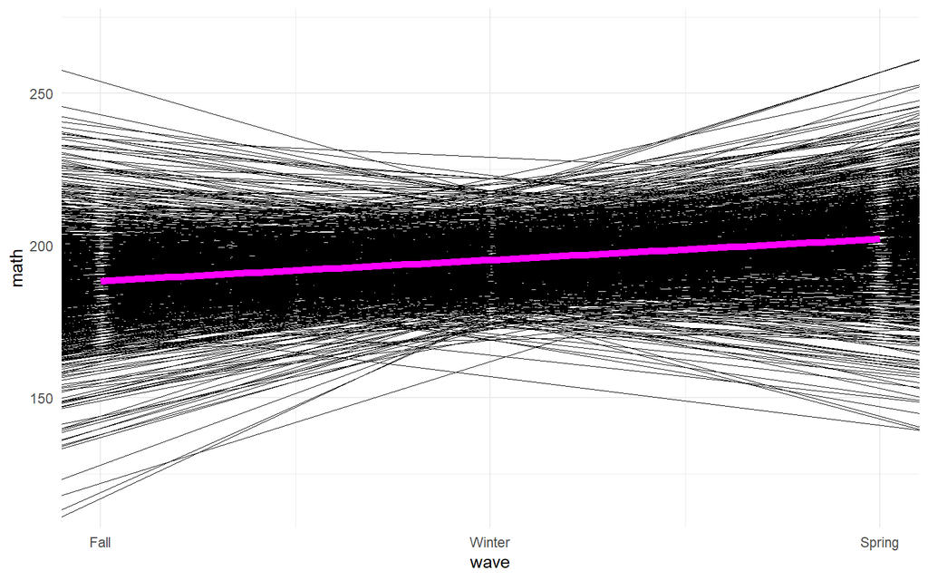

### Part B: Star Wars

Install and load the `{repurrrsive}` package

```r
install.packages("repurrrsive")
library(repurrrsive)
```

You now should have access to all the data you’ll need for the following.

1. There are 7 Star Wars films represented in the data (this is a hint of sorts). Use the `sw_films` list to identify how many characters were represented in each film.
2. Use the `sw_species` list to:
   1. identify species that have known hair colors, and
   2. identify what those hair colors are.

### Part C: Some basic API calls

Many of the list elements have urls for API calls. For example:

```r
repurrrsive::sw_films[[1]]$characters[1]
```

```
[1] "http://swapi.co/api/people/1/"
```

The above line of code provides the url necessary to make an API call for all the information available on the first character in the first film. Unfortunately, this API has since been deprecated. However, we’re going to use essentially equivalent API calls to instead obtain data about Pokemon, via https://pokeapi.co/. Feel free to visit the website and look around.

API’s are a way to host databases on the web, and make the data accessible via API calls. For example, the [tidycensus](https://walker-data.com/tidycensus/) package was an `R` package for interfacing with the US Census API. We’re going to look at abilities of Pokemon. For example to obtain data on the first ability, we could run the following:

```r
library(httr)

ability1 <- httr::GET("https://pokeapi.co/api/v2/ability/1") |>
    httr::content("parsed")
```

The last digit in `"https://pokeapi.co/api/v2/ability/1"` is just an index denoting that this is the first ability listed in the database. To obtain data on the third ability, we would instead change our call to `"https://pokeapi.co/api/v2/ability/3"`.

If you look at the parsed content (it comes in as JSON data) you will see it is a nested list, just like we worked with above for Star Wars.

We can identify what the specific *ability* is for `ability 1` with:

```r
ability1$name
```

```
[1] "stench"
```

and the *number of pokemon* with this ability with:

```r
length(ability1$pokemon)
```

```
[1] 10
```

1. Use `{purrr}` to write an API call to obtain data on the first five abilities (note, we’re only using the first five to make the calls go fast, but the code would be essentially equivalent for any number of abilities you wanted to query). Make sure you parse the JSON data to a list.
2. Use the parsed data to create a data frame that has the given ability, and the number of Pokemon with that ability.

#### Bonus: Up to 1 point extra credit

3. Create a new data frame that lists the names of the Pokemon with these specific abilities (just for the first 5 abiliites that you already extracted).

**Hint**: Try to get the name for one Pokemon first, then extend out the logic to get all Pokemon names. Also, this is really hard so don’t spend too much time on it and don’t worry if you can’t figure it out.